# High Frequency Analysis

Casey Tirshfield

## The file $\texttt{ibm_intrastrade_200306.txt}$ contains the transaction data on the New York Stock Exchange for IBM stock in June 2003. The data are obtained from Wharton Research Data Services.

```r
df <- read.table('ibm_intraday_200306.txt', header=TRUE)
# first we change the format of the date column to use the code inspired by https://stackoverflow.com/questions/15573468/split-or-subset-data-into-30-minute-intervals
df$DATE <- ymd(df$DATE)
```

### (a) Let $x_i$ denote the number of trades in the ith 5-minute interval. Ignoring the time gaps between trading days, this gives the time series $x_t$ of the number of trades on IBM stock in 5-minute intervals on the NYSE in June, 2003. Plot the time series and its ACF. Determine if there are intraday period patterns in the series.

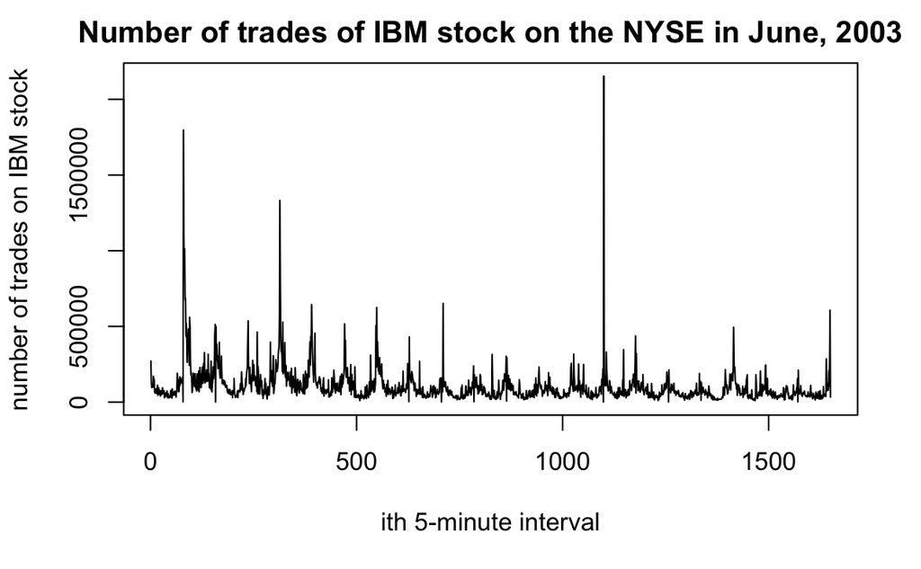

```r
# this is the inspired code that stores our data in separate data frames of 5-min periods
store_df <- split(df, cut(strptime(paste(df$DATE, df$TIME), format="%Y-%m-%d %H:%M:%S"), "5 mins"))
# here we take the sum of the number of trades per 5-min interval
list_freq <- lapply(store_df, function(x)sum(x$SIZE))
# in order to plot more easily we make the list a matrix
matrix_freq_w_0s <- matrix(unlist(list_freq), nrow=length(list_freq), byrow=TRUE)
# now we remove all rows with an entry of 0, thus ignoring the time gaps between trading days
freq_matrix <- matrix_freq_w_0s[apply(matrix_freq_w_0s!=0, 1, all),]
# plot series
plot(freq_matrix, type='l', xlab='ith 5-minute interval', ylab='number of trades on IBM stock', main='Number of trades of IBM stock on the NYSE in June, 2003')
# plot ACF
par(mar = c(4, 4, 4, 4))
```

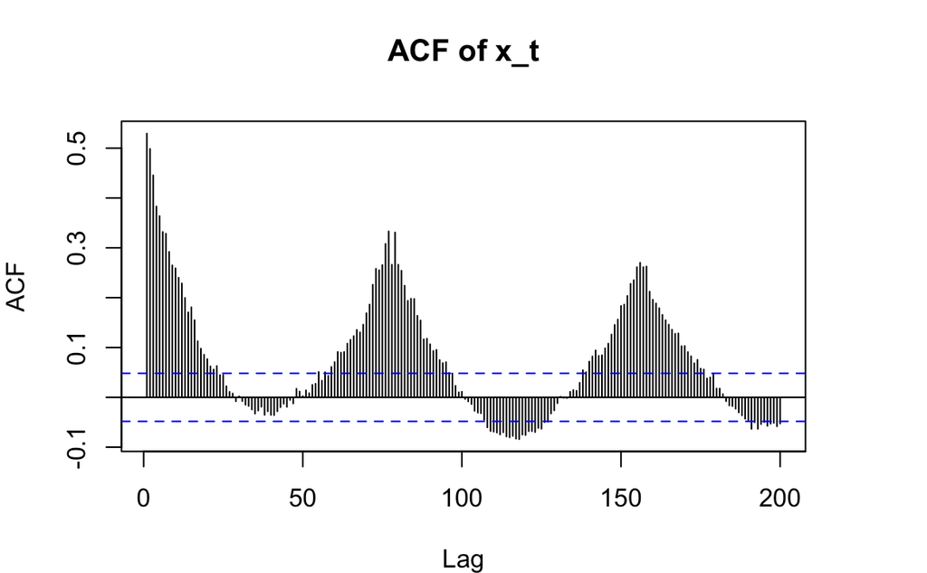

```r
Acf(freq_matrix, lag.max = 200, type = "correlation", plot = TRUE, na.action = na.contiguous, demean = TRUE, main='ACF of x_t')
```

```r
# discussion
print('From the plot of both the series and its ACF, it is easy to see that there are intraday period patterns characterized by spikes in the number of trades in the first seconds that the market is open and near the close. This seasonality is called U-Shaped (see page 289 of Tze Leung Lai and Haipeng Xings book, "Statistical Models and Methods for Financial Markets").')
```

[output not shown]

### (b) Using the last transaction price in the $i$th 5-minute interval as the stock price in that interval, plot the time series $y_t$ of 5-minute log returns during the period and the corresponding ACF.

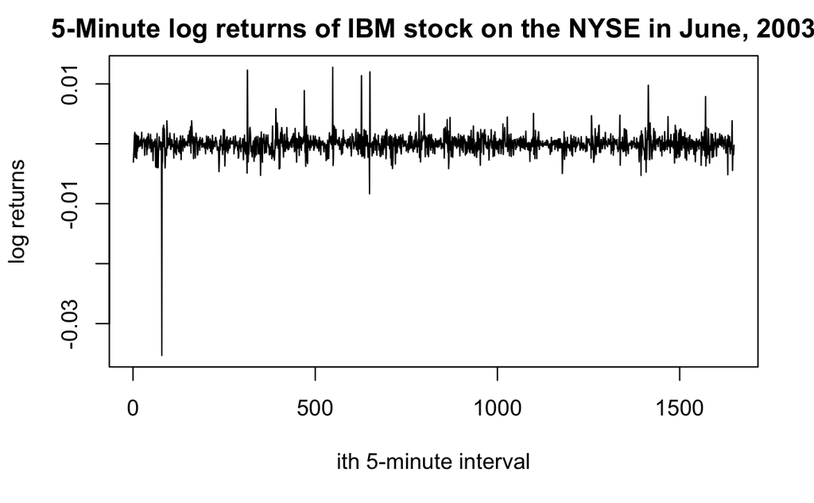

```r
# here we take the last transaction price per 5-min interval
list_price <- lapply(store_df, function(x)tail(x$PRICE, n=1))
# now we remove all rows with an entry of 0, thus ignoring the time gaps between trading days
list_price <- list_price[lapply(list_price, length)>0]
# in order to plot more easily we make the list a matrix
price_matrix <- matrix(unlist(list_price), nrow=length(list_price), byrow=TRUE)
# here we compute the time series of 5-minute log returns
log_returns <- diff(log(price_matrix), lag=1, differences=1)
# plot series
plot(log_returns, type='l', xlab='ith 5-minute interval', ylab='log returns', main='5-Minute log returns of IBM stock on the NYSE in June, 2003')
# plot ACF
par(mar = c(4, 4, 4, 4))
```

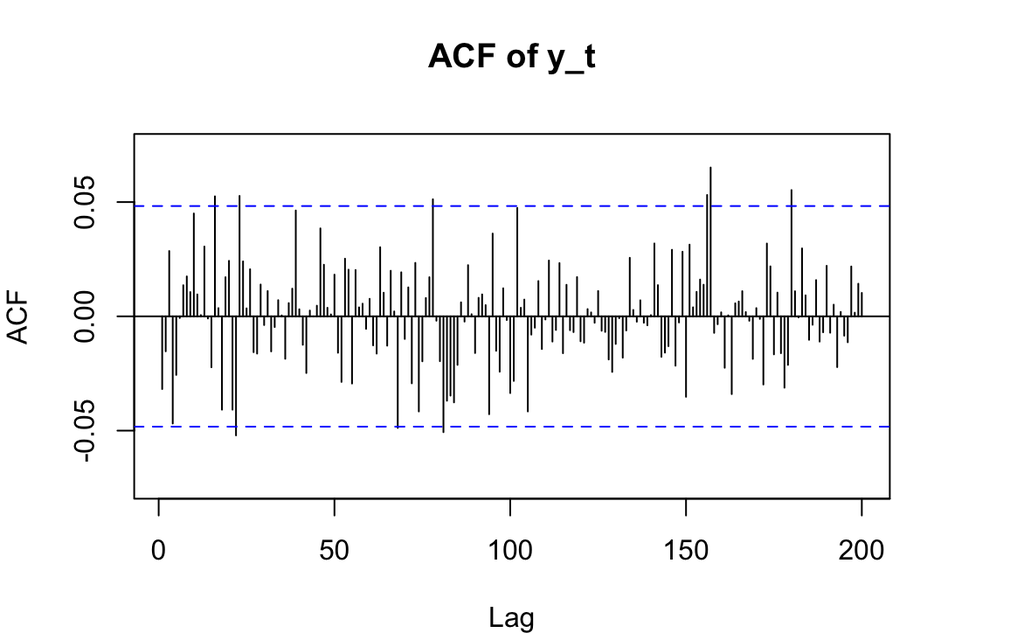

```r
Acf(log_returns, lag.max=200, type="correlation", plot=TRUE, na.action=na.contiguous, demean=TRUE, main='ACF of y_t')
```